# UD 1. Introducción a Android

José Ángel González Molina

22 de septiembre de 2023

## Programación de móviles con Android

[figure not shown]

## ¿Qué es Android?

- Sistema operativo para dispositivos móviles
- Framework de desarrollo para construir aplicaciones para móviles
- **La diferencia es el uso del "apellido" SDK para referirnos a uno u otro**

## Android SDK

> Es un framework de desarrollo, es decir, un conjunto de herramientas que nos permite construir aplicaciones que puedan correr en un dispositivo móvil. Además incluye utilidades como un conjunto de librerías y emuladores de dispositivos reales.

## ¿Dónde programar?

> Puesto que los frameworks o SDKs no incluyen el IDE con el que el programador debe escribir el código, en los últimos años, Google desarrolló *Android Studio*,un IDE completo para su uso con el framework.

### Android Studio

# Estructura de Android

## Estructura del Sistema Operativo

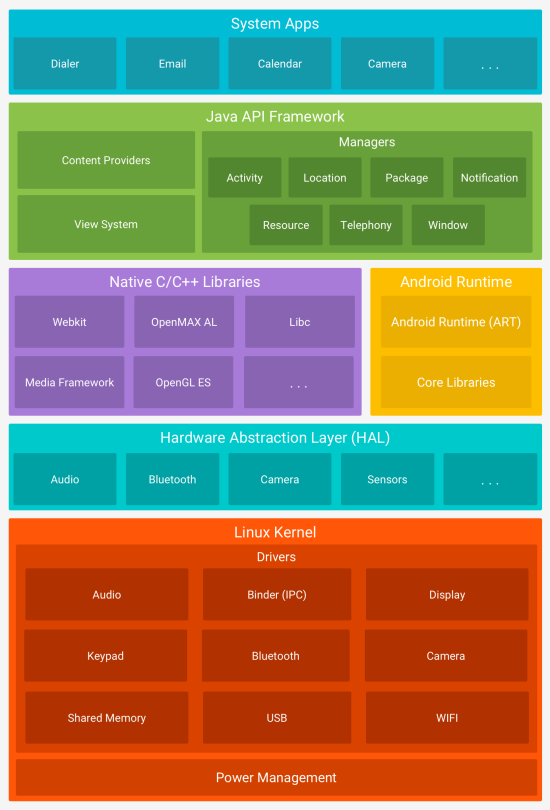

## Ciclo de vida de una aplicación

[output not shown]

## Estructura de una aplicación

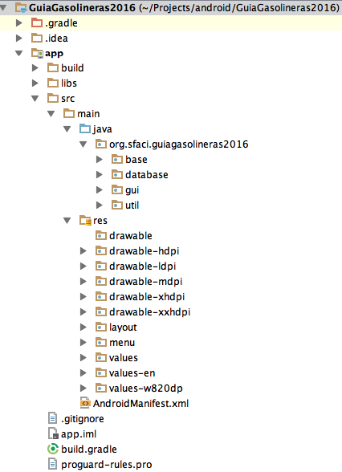

- **libs** Carpeta con las librerías externas que usamos
- **src** Carpeta que contiene el código *Java* de la aplicación.
- **res** Recursos que utiliza la aplicación (imágenes, layouts, textos, . . .)
- **res→drawable-xxxx** Imágenes e iconos organizados por resolución
- **res→layout** Diseños de las interfaces de usuario
- **res→menu** Ficheros que describen los elementos de los menús
- **res→values** Ficheros con la descripción de palabras por idioma
- **res→values-en** Fichero con las palabras de un idioma (inglés)
- **AndroidManifest.xml** Fichero en el que detallamos algunos aspectos importantes
- **build.gradle** Configuración de *gradle* para construir la aplicación

## Código de la aplicación

- Se debe empaquetar con la jerarquía y nombrado de paquetes indicados en: [🌎convenciones de código de Java](http://docs.oracle.com/javase/tutorial/java/package/namingpkgs.html).
- Conviene seguir la reglas definidas en su [🌎Guía de estilo para contribuidores](http://source.android.com/source/code-style.html).
- Todo ello debe coincidir con lo especificado en el fichero `AndroidManifest.xml`.

## Recursos de imagen (drawable)

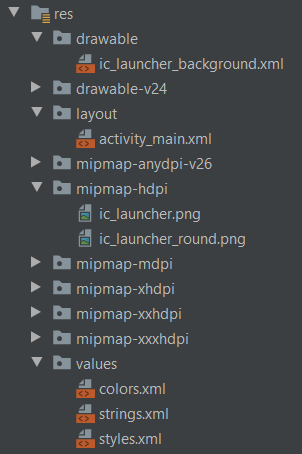

- /drawable (recursos independientes de la densidad)
- /drawable-ldpi (densidad baja)
- /drawable-mdpi (densidad media)
- /drawable-hdpi (densidad alta)
- /drawable-xhdpi (densidad muy alta)
- /drawable-xxhdpi (densidad muy muy alta)

Se puede observar un sufijo adicional, como en «drawable-**v24**«. Estos sufijos determinan algunos dispositivos por características comunes. La lista completa está en [documentación oficial de Android](http://developer.android.com/guide/topics/resources/providing-resources.html)

## Recursos de layout (layouts)

Aquí se almacenan los ficheros que contienen los layouts (diseños) de la aplicación. Lo más habitual será encontrar un layout por cada `Activity` que se haya creado, pero al igual que necesitaremos crear clases Java que no estén asociadas con ninguna pantalla, también podemos encontrar layouts que no estén vinculados con ninguna Activity porque sean parte de otros layouts más complejos. Por ejemplo, en una Activity podremos diseñar un layout que sea una lista de elementos, que a su vez serán otro layout. De esa forma podremos diseñar el aspecto de cada uno de los elementos y luego listar tantos elementos como haya en una lista, utilizando el mismo layout para cada uno de ellos.

#### Recursos de idioma (values)

Aquí se almacenan los ficheros que contienen todos los textos de la aplicación. El objetivo es separar totalmente el código de la aplicación del texto con la finalidad de simplificar la internacionalización de la misma. De esa manera, cuando se quiera traducir la aplicación a un nuevo idioma bastará con crear el fichero correspondiente con los textos en dicho idioma y no será necesario realizar ningún cambio en el código.

Por defecto, en la carpeta `values` nos encontraremos con los ficheros en el idioma por defecto. En nuestro caso sería el español.

#### Fichero de textos

El fichero principal que encontramos en esta carpeta `values` es `strings.xml`, que contiene todos los textos de la aplicación acompañados de una cadena que funciona de identificador, para poder hacer referencia a cada cadena desde el código.

```xml
<resources>
  <string name="app_name">Agenda</string>
  <string name="action_settings">Settings</string>
  <string name="title_activity_nuevo_contacto">Nuevo Contacto</string>
  <string name="title_activity_preferencias">Preferencias</string>
  <string name="acerca_de_title">Acerca de Agendroid v2</string>

  <string name="menu_nuevo_contacto_label">Nuevo Contacto</string>
  <string name="menu_preferencias_label">Preferencias</string>

  <string name="nombre_label">Nombre</string>
  <string name="apellidos_label">Apellidos</string>
  <string name="telefono_label">Teléfono</string>
  <string name="movil_label">Móvil</string>
  <string name="fax_label">Fax</string>
  <string name="favorito_label">Favorito</string>
  <string name="btaceptar_label">Aceptar</string>
  <string name="btcancelar_label">Cerrar</string>
  <string name="btimagen_label">Imagen</string>
  <string name="tvsindatos_label">No hay contactos</string>
  <string name="menu_acerca_de_label">Acerca de</string>

  <string name="nuevo_contacto_message">Contacto Añadido</string>
  <string name="esta_seguro_message">¿Está seguro?</string>
  <string name="acerca_de_message">Agendroid v2\nAgenda para Android\n(c) 2013 Santiago Faci</string>

  <string name="llamar_telefono_item">Llamar a casa</string>
  <string name="llamar_movil_item">Llamar al móvil</string>
  <string name="eliminar_item">Eliminar</string>
</resources>
```

Así, en el caso de que queramos traducir esta aplicación al inglés, sólo tenemos que hacer una copia de este fichero, moverlo a una carpeta `values-en` y traducir los textos, dejando intacta la cadena identificadora de cada uno de ellos. De esa forma, cuando hagamos referencia a una cadena, será Android quién decida en que idioma escribirla dependiendo del idioma que el usuario tenga configurado en su dispositivo móvil.

```xml
<resources>
  <string name="app_name">Contacts</string>
  <string name="action_settings">Settings</string>
  <string name="title_activity_nuevo_contacto">New Contact</string>
  <string name="title_activity_preferencias">Preferences</string>
  <string name="acerca_de_title">About Agendroid v2</string>

  <string name="menu_nuevo_contacto_label">New Contact</string>
  <string name="menu_preferencias_label">Preferences</string>

  <string name="nombre_label">Name</string>
  <string name="apellidos_label">Last name</string>
  <string name="telefono_label">Phone</string>
  <string name="movil_label">Mobile</string>
  <string name="fax_label">Fax</string>
  <string name="favorito_label">Favorite</string>
  <string name="btaceptar_label">Accept</string>
  <string name="btcancelar_label">Close</string>
  <string name="menu_acerca_de_label">About</string>

  <string name="nuevo_contacto_message">Contact Added</string>
  <string name="esta_seguro_message">Are you sure?</string>
  <string name="acerca_de_message">Agendroid v2\nAndroid Contacts App\n(c) 2013 Santiago Faci</string>

  <string name="btimagen_label">Image</string>

  <string name="tvsindatos_label">No data</string>

  <string name="llamar_telefono_item">Call Home</string>
  <string name="llamar_movil_item">Call Mobile</string>
  <string name="eliminar_item">Delete</string>
</resources>
```

Así, si queremos desde el código, mostrar un mensaje con alguno de estos textos en una `TextView`, podemos hacerlo de la siguiente forma:

```java
. . .
ViewText vtMensaje;
. . .
vtMensaje.setText(getResources().getString(R.string.nuevo_contacto_message));
. . .
```

También podremos, donde se admita un `int` indicando el identificador de la cadena (por ejemplo para mostrar mensajes emergentes con `Toast`), usar las cadenas de la siguiente forma:

```java
Toas.makeText(this, R.string.nuevo_contacto_message, Toast.LENGTH_SHORT).show();
```

#### Arrays de textos

También se pueden crear *arrays* de datos que luego pueden ser usados desde el código de la aplicación. El siguiente lo almacenaríamos en la carpeta `values` puesto que esta en español. Para traducirlo procederíamos de la misma forma que hemos hecho para traducir los textos de la aplicación.

```xml
<resources>
  <string-array name="datos">
    <item>Nombre</item>
    <item>Apellidos</item>
  </string-array>
</resources>
```

Fichero traducido y almacenado en `values-en`.

```xml
<resources>
  <string-array name="datos">
    <item>Name</item>
    <item>Lastname</item>
 </string-array>
</resources>
```

#### Fichero de manifiesto AndroidManifest.xml

A continuación se muestra como ejemplo un fichero `AndroidManifest.xml` de una aplicación de ejemplo. A continuación se explicarán cada una de las partes que lo forman.

```xml
<?xml version="1.0" encoding="utf-8"?>
<manifest xmlns:android="http://schemas.android.com/apk/res/android"
  package="org.sfaci.guiarestaurantes" >

  <application
    android:allowBackup="true"
    android:icon="@drawable/ic_launcher"
    android:label="@string/app_name"
    android:theme="@style/AppTheme" >

    <uses-permission android:name="android.permission.INTERNET"/>
    <uses-permission android:name="android.permission.ACCESS_NETWORK_STATE"/>
    <uses-permission android:name="android.permission.WRITE_EXTERNAL_STORAGE"/>
    <uses-permission android:name="com.google.android.providers.gsf.permission.READ_GSERVICES"/>

    <activity
          android:name=".ListadoRestaurantes"
          android:label="@string/app_name" >
          <intent-filter>
              <action android:name="android.intent.action.MAIN" />

              <category android:name="android.intent.category.LAUNCHER" />
          </intent-filter>
    </activity>
    <activity
          android:name=".Mapa"
          android:label="@string/title_activity_mapa" >
    </activity>

      <meta-data
          android:name="com.google.android.maps.v2.API_KEY"
          android:value="AIzaSyB2JUyHKX1WCg9Jj-rLDW6HicSs_6_lvac"/>
  </application>
</manifest>
```

- `package` Con este parámetro indicamos el paquete base de nuestra aplicación.
- `<uses-permission>` Pueden aparecer tantas líneas como permisos sea necesario activar en la aplicación. Los permisos permiten que la aplicación haga uso de determinadas características del móvil de las que debe ser notificado el usuario a la hora de instalarla, tales como el uso de Internet, acceso al GPS, acceso a la tarjeta de memoria y otras.
- `<activity>…</activity>` Cada una de estas etiquetas indica la existencia de una Activity. Se añaden de forma automática cuando se crea la Activity desde el IDE.
- `<intent-filter> . . . android.intent.action.MAIN . . . </intent-filter>` Estas 4 líneas se colocan dentro de las etiquetas de la *Activity* que queremos marcar como *Activity* principal que será la primera que se lance cuando se ejecute la aplicación.
- `<meta-data . . . />` En este caso utilizamos esta etiqueta para indicar información adicional como el *API KEY* de Google Maps para utilizar los mapas en la aplicación.

## Cómo comenzar

Después de [instalar nuestro entorno de desarrollo para Android](https://www.sgoliver.net/blog/entorno-de-desarrollo-android-android-studio/) y comentar la [estructura básica de un proyecto](https://www.sgoliver.net/blog/entorno-de-desarrollo-android-android-studio/) y los diferentes [componentes software](https://www.sgoliver.net/blog/componentes-de-una-aplicacion-android/) que podemos utilizar ya es hora de empezar a escribir algo de código. Y como siempre lo mejor es empezar por escribir una aplicación sencilla.

En un principio me planteé analizar en este capítulo el clásico *Hola Mundo* pero más tarde me pareció que se iban a quedar algunas cosas básicas en el tintero. Así que he versionado a mi manera el *Hola Mundo* transformándolo en algo así como un *Hola Usuario*, que es igual de sencilla pero añade un par de cosas interesantes de contar.

La aplicación constará de dos pantallas, por un lado la pantalla principal que solicitará un nombre al usuario y una segunda pantalla en la que se mostrará un mensaje personalizado para el usuario. Así de sencillo e inútil, pero aprenderemos muchos conceptos básicos, que para empezar no está mal.

Por dibujarlo para entender mejor lo que queremos conseguir, sería algo tan sencillo como lo siguiente:

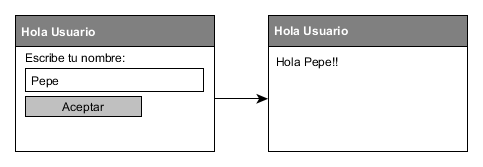

Como ya vimos, Android Studio había creado por nosotros la estructura de carpetas del proyecto y todos los ficheros necesarios de un *Hola Mundo* básico, es decir, una sola pantalla donde se muestra únicamente un mensaje fijo.

Lo primero que vamos a hacer es diseñar nuestra pantalla principal modificando la que Android Studio nos ha creado por defecto. Aunque ya lo habíamos comentado de pasada, recordemos dónde y cómo se define cada pantalla de la aplicación. En Android, el diseño y la lógica de una pantalla están separados en dos ficheros distintos. Por un lado, en el fichero */src/main/res/layout/activity_main.xml* tendremos el diseño puramente visual de la pantalla definido como fichero XML y por otro lado, en el fichero */src/main/java/mi.paquete.java/MainActivity.java*, encontraremos el código java que determina la lógica de la pantalla.

Vamos a modificar en primer lugar el aspecto de la ventana (*activity*) principal de la aplicación añadiendo los controles (*views*) que vemos en el esquema mostrado al principio del apartado. Para ello, vamos a sustituir el contenido completo del fichero *activity_main.xml* por el siguiente:

```xml
<?xml version="1.0" encoding="utf-8"?>
<LinearLayout xmlns:android="http://schemas.android.com/apk/res/android"
    android:id="@+id/lytContenedor"
    android:layout_width="match_parent"
    android:layout_height="match_parent"
    android:orientation="vertical" >

    <TextView android:id="@+id/lblNombre"
        android:layout_width="wrap_content"
        android:layout_height="wrap_content"
        android:text="@string/nombre" />

    <EditText android:id="@+id/txtNombre"
        android:layout_width="match_parent"
        android:layout_height="wrap_content"
        android:inputType="text" />

    <Button android:id="@+id/btnAceptar"
        android:layout_width="wrap_content"
        android:layout_height="wrap_content"
        android:text="@string/aceptar" />

</LinearLayout>
```

Recuerda que si no ves el código XML al abrir el fichero del layout, puedes alternar entre el editor visual y el de código con los botones de la esquina superior derecha de la ventana, como comentamos en el artículo anterior sobre la [estructura de un proyecto de Android Studio](https://www.sgoliver.net/blog/estructura-de-un-proyecto-android-android-studio/).

Al pegar este código en el fichero de layout aparecerán algunos errores marcados en rojo, en los valores de los atributos `android:text`. Es normal, lo arreglaremos pronto.

En este XML se definen los elementos visuales que componen la interfaz de nuestra pantalla principal y se especifican todas sus propiedades. No nos detendremos mucho por ahora en cada detalle, pero expliquemos un poco lo que vemos en el fichero.

Lo primero que nos encontramos es un elemento `LinearLayout`. Los componentes de tipo *layout* son elementos no visibles que determinan cómo se van a distribuir en el espacio los controles que incluyamos en su interior. Los programadores java, y más concretamente de *Swing* (aquellos que aún recuerden qué es eso), conocerán este concepto perfectamente. En este caso, un `LinearLayout` distribuirá los controles simplemente uno tras otro y en la orientación que indique su propiedad `android:orientation`, que en este caso será “vertical”.

Dentro del *layout* hemos incluido 3 controles: una etiqueta (`TextView`), un cuadro de texto (`EditText`), y un botón (`Button`). En todos ellos hemos establecido las siguientes propiedades:

- `android:id`. ID del control, con el que podremos identificarlo más tarde en nuestro código. Vemos que el identificador lo escribimos precedido de “@+id/”. Esto tendrá como efecto que al compilarse el proyecto se genere automáticamente una nueva constante en la clase `R` para dicho control. Así, por ejemplo, como al cuadro de texto le hemos asignado el ID «txtNombre», podremos más tarde acceder al él desde nuestro código java haciendo referencia a la constante `R.id.txtNombre`
- `android:layout_height` y `android:layout_width`. Dimensiones del control con respecto al layout que lo contiene (*height*=alto, *width*=ancho). Esta propiedad tomará normalmente los valores “wrap_content” para indicar que las dimensiones del control se ajustarán al contenido del mismo, o bien “match_parent” para indicar que el ancho o el alto del control se ajustará al ancho o alto del layout contenedor respectivamente.

Además de estas propiedades comunes a casi todos los controles que utilizaremos, en el cuadro de texto hemos establecido también la propiedad `android:inputType`, que indica qué tipo de contenido va a albergar el control, en este caso será texto general (valor «text»), aunque podría haber sido una contraseña (valor «textPassword»), un teléfono («phone»), una fecha («date»), ….

Por último, en la etiqueta y el botón hemos establecido la propiedad `android:text`, que indica el texto que aparece en el control. Y aquí nos vamos a detener un poco, ya que tenemos dos alternativas a la hora de hacer esto. En Android, el texto de un control se puede especificar directamente como valor de la propiedad `android:text`, o bien utilizar alguna de las cadenas de texto definidas en los recursos del proyecto (como ya vimos, en el fichero *strings.xml*), en cuyo caso indicaremos como valor de la propiedad `android:text` su identificador precedido del prefijo «@string/».

Dicho de otra forma, la primera alternativa habría sido indicar directamente el texto como valor de la propiedad, por ejemplo en la etiqueta de esta forma:

```xml
<TextView android:id="@+id/lblNombre"
    android:layout_width="wrap_content"
    android:layout_height="wrap_content"
    android:text="Escribe tu nombre:" />
```

Y la segunda alternativa, la opción más recomendada y la que utilizo en este ejemplo, consistiría en definir primero una nueva cadena de texto en el fichero de recursos */src/main/res/values/strings.xml*, por ejemplo con identificador “nombre” y valor “Escribe tu nombre:”.

```xml
<resources>
    ...
    <string name="nombre">Escribe tu nombre:</string>
    ...
</resources>
```

Y posteriormente indicar el identificador de dicha cadena como valor de la propiedad `android:text`, siempre precedido del prefijo “@string/”, de la siguiente forma:

```xml
<TextView android:id="@+id/lblNombre"
    android:layout_width="wrap_content"
    android:layout_height="wrap_content"
    android:text="@string/nombre" />
```

Esta segunda alternativa nos permite tener perfectamente localizadas y agrupadas todas las cadenas de texto utilizadas en la aplicación, lo que nos podría facilitar por ejemplo la traducción de la aplicación a otro idioma. Haremos esto para las dos cadenas de texto utilizadas en el layout, «nombre» y «aceptar». Una vez incluidas ambas cadenas de texto en el fichero *strings.xml* deberían desaparecer los dos errores marcados en rojo que nos aparecieron antes en la ventana *activity_main.xml*.

```java
package com.example.pruebaandroid;

import androidx.appcompat.app.AppCompatActivity;
import android.os.Bundle;

public class MainActivity extends AppCompatActivity {

    private EditText txtNombre;
    private Button btnAceptar;

    @Override
    protected void onCreate(Bundle savedInstanceState) {
        super.onCreate(savedInstanceState);
        setContentView(R.layout.activity_main);
    }
}
```

Como ya vimos en un apartado anterior, las diferentes pantallas de una aplicación Android se definen mediante objetos de tipo `Activity`. Por tanto, lo primero que encontramos en nuestro fichero java es la definición de una nueva clase `MainActivity` que extiende en este caso de un tipo especial de `Activity` llamado `AppCompatActivity`, que soporta entre otras cosas la utilización de la *Action Bar* en nuestras aplicaciones (la *action bar* es la barra de título y menú superior que se utiliza en la mayoría de aplicaciones Android). El único método que modificaremos por ahora en esta clase será el método `onCreate()`, llamado cuando se crea por primera vez la actividad. En este método lo único que encontramos en principio, además de la llamada a su implementación en la clase padre, es la llamada al método `setContentView(R.layout.activity_main)`. Con esta llamada estaremos indicando a Android que debe establecer como interfaz gráfica de esta actividad la definida en el recurso `R.layout.activity_main`, que no es más que la que hemos especificado en el fichero */src/main/res/layout/activity_main.xml*. Una vez más vemos la utilidad de las diferentes constantes de recursos creadas automáticamente en la clase `R` al compilar el proyecto.

Antes de modificar el código de nuestra actividad principal, vamos a crear una nueva actividad para la segunda pantalla de la aplicación análoga a ésta primera, a la que llamaremos `SaludoActivity`.

Para ello, accederemos al menú File y seleccionaremos la opción de menú New/Activity/Empty Activity.

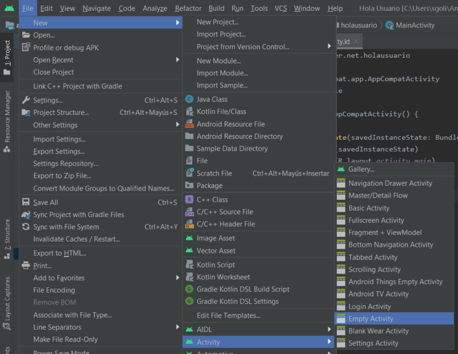

En el cuadro de diálogo que nos aparece indicaremos el nombre de la actividad, en nuestro caso «SaludoActivity», el nombre de su layout XML asociado (Android Studio creará al mismo tiempo tanto el layout XML como la clase java), que llamaremos «activity_saludo», el nombre del paquete java de la actividad que podemos dejar con su valor por defecto, y el lenguaje a utilizar, siempre Java.

[figure not shown]

Pulsaremos *Finish* y Android Studio creará los nuevos ficheros *SaludoActivity.java* y *activity_saludo.xml* en sus carpetas correspondientes.

De igual forma que hicimos con la actividad principal, definiremos en primer lugar la interfaz de la segunda pantalla, abriendo el fichero *activity_saludo.xml*, y añadiendo esta vez tan sólo un `LinearLayout` como contenedor y una etiqueta (`TextView`) para mostrar el mensaje personalizado al usuario. Para esta segunda pantalla el código que incluiríamos sería el siguiente:

```xml
<LinearLayout xmlns:android="http://schemas.android.com/apk/res/android"
    android:id="@+id/lytContenedorSaludo"
    android:layout_width="match_parent"
    android:layout_height="match_parent"
    android:orientation="vertical" >

    <TextView android:id="@+id/txtSaludo"
        android:layout_width="wrap_content"
        android:layout_height="wrap_content"
        android:text="" />

</LinearLayout>
```

Por su parte, si revisamos ahora el código de la clase `SaludoActivity` veremos que es análogo a la actividad principal:

```java
package com.example.pruebaandroid;

import androidx.appcompat.app.AppCompatActivity;
import android.os.Bundle;

public class SaludoActivity extends AppCompatActivity {

    @Override
    protected void onCreate(Bundle savedInstanceState) {
        super.onCreate(savedInstanceState);
        setContentView(R.layout.activity_saludo);
    }
}
```

Sigamos. Por ahora, el código incluido en estas clases lo único que hace es generar la interfaz de la actividad. A partir de aquí nosotros tendremos que incluir el resto de la lógica de la aplicación.

Y vamos a empezar con la actividad principal `MainActivity`, obteniendo una referencia a los diferentes controles de la interfaz que necesitemos manipular, en nuestro caso sólo el cuadro de texto y el botón. Para ello definiremos ambas referencias como propiedades de la clase y para obtenerlas utilizaremos el método `findViewById()` indicando el ID de cada control, definidos como siempre en la clase `R`. Todo esto lo haremos dentro del método `onCreate()` de la clase `MainActivity`, justo a continuación de la llamada a `setContentView()` que ya comentamos.

```java
package com.example.pruebaandroid;

import androidx.appcompat.app.AppCompatActivity;
import android.os.Bundle;
import android.widget.Button;
import android.widget.EditText;

public class MainActivity extends AppCompatActivity {

    private EditText txtNombre;
    private Button btnAceptar;

    @Override
    protected void onCreate(Bundle savedInstanceState) {
        super.onCreate(savedInstanceState);
        setContentView(R.layout.activity_main);

        // Obtenemos una referencia a los controles de la interfaz
        txtNombre = findViewById(R.id.txtNombre);
        btnAceptar = findViewById(R.id.btnAceptar);
    }
}
```

Como vemos, hemos añadido también varios `import` adicionales (los de las clases `Button` y `EditText`) para tener acceso a todas las clases utilizadas.

Una vez tenemos acceso a los diferentes controles, ya sólo nos queda implementar las acciones a realizar cuando pulsemos el botón. Para ello, continuando el código anterior, y siempre dentro del método `onCreate()`, implementaremos el evento `onClick` de dicho botón. Este botón tendrá que ocuparse de abrir la actividad `SaludoActivity` pasándole toda la información necesaria. Veamos cómo:

```java
package com.example.pruebaandroid;


import android.content.Intent;
import android.os.Bundle;
import android.view.View;
import android.widget.Button;
import android.widget.EditText;
import androidx.appcompat.app.AppCompatActivity;

public class MainActivity extends AppCompatActivity {

    private EditText txtNombre;
    private Button btnAceptar;

    @Override
    protected void onCreate(Bundle savedInstanceState) {
        super.onCreate(savedInstanceState);
        setContentView(R.layout.activity_main);

        // Obtenemos una referencia a los controles de la interfaz
        txtNombre = findViewById(R.id.txtNombre);
        btnAceptar = findViewById(R.id.btnAceptar);

        btnAceptar.setOnClickListener(new View.OnClickListener() {
            @Override
            public void onClick(View v) {
                // Creamos el Intent
                Intent intent = new Intent(MainActivity.this, SaludoActivity.class);

                // Añadimos al intent la información a pasar entre actividades
                intent.putExtra("NOMBRE", txtNombre.getText().toString());

                // Iniciamos la nueva actividad
                startActivity(intent);
            }
        });
    }
}
```

Si necesitáramos pasar más datos entre una actividad y otra no tendríamos más que repetir la llamada a `putExtra()` para todos los datos necesarios.

```java
package com.example.pruebaandroid;

import android.os.Bundle;
import android.widget.TextView;
import androidx.appcompat.app.AppCompatActivity;

public class SaludoActivity extends AppCompatActivity {

    private TextView txtSaludo;

    @Override
    protected void onCreate(Bundle savedInstanceState) {
        super.onCreate(savedInstanceState);
        setContentView(R.layout.activity_saludo);

        // Obtenemos una referencia a los controles de la interfaz
        txtSaludo = findViewById(R.id.txtSaludo);

        // Recuperamos la información pasada en el intent
        String saludo = getIntent().getStringExtra("NOMBRE");

        // Construimos el mensaje a mostrar
        txtSaludo.setText("Hola " + saludo);
    }
}
```

Con esto hemos concluido la lógica de las dos pantallas de nuestra aplicación y tan sólo nos queda un paso importante para finalizar nuestro desarrollo. Como ya indicamos en un apartado anterior, toda aplicación Android utiliza un fichero especial en formato XML llamado *AndroidManifest.xml* para definir, entre otras cosas, los diferentes elementos que la componen. Por tanto, todas las actividades de nuestra aplicación deben quedar convenientemente definidas en este fichero. En este caso, Android Studio se debe haber ocupado por nosotros de definir ambas actividades en el fichero, pero lo revisaremos para así echar un vistazo al contenido.

Si abrimos el fichero *AndroidManifest.xml* veremos que contiene un elemento principal `<application>` que debe incluir varios elementos `<activity>`, uno por cada actividad incluida en nuestra aplicación. En este caso, comprobamos como efectivamente Android Studio ya se ha ocupado de esto por nosotros, aunque este fichero sí podríamos modificarlo a mano para hacer ajustes si fuera necesario.

```xml
<?xml version="1.0" encoding="utf-8"?>
<manifest xmlns:android="http://schemas.android.com/apk/res/android"
    package="android.sgoliver.net.holausuario">

    <application
        android:allowBackup="true"
        android:icon="@mipmap/ic_launcher"
        android:label="@string/app_name"
        android:roundIcon="@mipmap/ic_launcher_round"
        android:supportsRtl="true"
        android:theme="@style/AppTheme">
        <activity android:name=".SaludoActivity"></activity>
        <activity android:name=".MainActivity">
            <intent-filter>
                <action android:name="android.intent.action.MAIN" />
                <category android:name="android.intent.category.LAUNCHER" />
            </intent-filter>
        </activity>
    </application>
</manifest>
```

Podemos ver como para cada actividad se indica entre otras cosas el nombre de su clase java asociada como valor del atributo `android:name`, más adelante veremos qué opciones adicionales podemos especificar.

El último elemento que revisaremos de nuestro proyecto, aunque tampoco tendremos que modificarlo por ahora, será el fichero *build.gradle*. Pueden existir varios ficheros llamados así en nuestra estructura de carpetas, a distintos niveles, pero normalmente siempre accederemos al que está al nivel más interno, en nuestro caso el que está dentro del módulo «app». Veamos qué contiene:

```
plugins {
    id 'com.android.application'
}

android {
    namespace 'com.example.pruebaandroid'
    compileSdk 33

    defaultConfig {
        applicationId "com.example.pruebaandroid"
        minSdk 26
        targetSdk 33
        versionCode 1
        versionName "1.0"

        testInstrumentationRunner "androidx.test.runner.AndroidJUnitRunner"
    }

    buildTypes {
        release {
            minifyEnabled false
            proguardFiles getDefaultProguardFile('proguard-android-optimize.txt'), 'proguard-rules.pro'
        }
    }
    compileOptions {
        sourceCompatibility JavaVersion.VERSION_1_8
        targetCompatibility JavaVersion.VERSION_1_8
    }
}

dependencies {

    implementation 'androidx.appcompat:appcompat:1.6.1'
    implementation 'com.google.android.material:material:1.9.0'
    implementation 'androidx.constraintlayout:constraintlayout:2.1.4'
    testImplementation 'junit:junit:4.13.2'
    androidTestImplementation 'androidx.test.ext:junit:1.1.5'
    androidTestImplementation 'androidx.test.espresso:espresso-core:3.5.1'
}
```

Llegados aquí, y si todo ha ido bien, deberíamos poder ejecutar ya el proyecto sin errores y probar nuestra aplicación en el emulador. Vamos a hablar un poco de este tema.

Para poder probar aplicaciones Android en nuestro PC, sin tener que recurrir a un dispositivo físico (aunque por supuesto también es posible), tenemos que definir lo que se denomina un *AVD* o *Android Virtual Device*. Si seguiste el artículo de [instalación del entorno de desarrollo](https://www.sgoliver.net/blog/entorno-de-desarrollo-android-android-studio/) ya deberías tener un AVD creado y disponible para probar (si no es así no te preocupes, en breve veremos como crear uno nuevo). Lo podemos comprobar accediendo al menú Tools/AVD Manager.

[figure not shown]

La herramienta AVD Manager nos permite crear y gestionar dispositivos virtuales de Android (AVD), que como hemos comentado serán nuestro sustituto de un dispositivo físico a la hora de probar y depurar en el PC nuestras aplicaciones. En la ventana inicial del AVD Manager podemos ver los AVD que ya tenemos creados y disponibles para utilizar. Como puedes ver en la captura anterior, en mi caso particular tengo disponible un AVD llamado «Nexus 5X API 29 x86». Éste es el AVD que Android Studio ha creado por nosotros durante el proceso de instalación. En la misma lista podemos comprobar las características principales de este AVD, como las dimensiones y la resolución de la pantalla, o el nivel de API Android que utiliza (la 29 en mi caso, que equivale a Android 10).

Una vez comprobado que tenemos un AVD disponible, podemos cerrar ya el AVD Manager y disponernos a ejecutar nuestra aplicación en el emulador de Android sobre este AVD. Para ello, podemos dirigirnos a la barra de herramientas superior, desde donde podemos seleccionar el AVD que queremos utilizar para ejecutar la aplicación (podemos tener varios AVD creados, en cuyo caso tendremos que seleccionar uno de ellos en la lista desplegable) y pulsar el botón verde justo a su derecha para iniciar la ejecución (o bien el menú Run/Run ‘app’).

[figure not shown]

Si todo va bien, debería abrirse el emulador de Android, e iniciarse nuestra aplicación. Si es la primera vez que inicias el emulador y/o un AVD determinado es posible que la primera ejecución se demore algún tiempo. Ejecuciones posteriores deberían ser más rápidas.

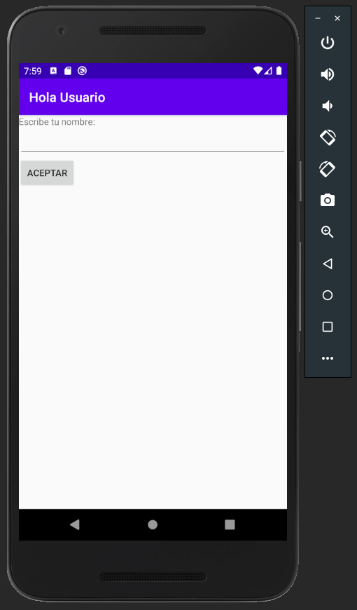

En la imagen anterior podemos ver nuestra primera aplicación ya iniciada en el emulador de Android. Podemos probar a escribir un nombre en el cuadro de texto y pulsar el botón “ACEPTAR” para comprobar si el funcionamiento es el esperado.

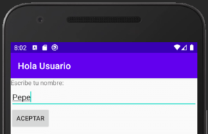

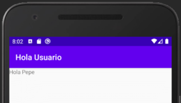

Ya hemos desarrollado y ejecutado nuestra primera aplicación en el emulador de Android.

Si quisiéramos crear otro AVD, por ejemplo para probar nuestra aplicación sobre otra resolución de pantalla, o sobre otra versión de Android, podemos volver de nuevo la herramienta AVD Manager, accediendo al menú Tools/AVD Manager.

Para crear un nuevo AVD pulsaremos el botón «Create Virtual Device…» situado en la esquina inferior izquierda del AVD Manager. Esto iniciará el asistente de creación de un AVD. En la primera pantalla tendremos que seleccionar el tipo de dispositivo que queremos crear: teléfono, tablet, smartwatch (Wear OS), Android TV, o Android Auto. Una vez seleccionado el tipo de dispositivo, podemos seleccionar las características concretas del dispositivo (tamaño, resolución, y densidad de píxeles de su pantalla, memoria, cámaras, …). Para ellos podremos elegir entre una lista predefinida de modelos reales de dispositivo, algunos modelos genéricos, o bien definir nuestro propio dispositivo a medida pulsando el botón «New Hardware Profile».

[figure not shown]

En mi caso seleccionaré el modelo «Pixel 3a». Pulsaremos el botón *Next* para continuar con el proceso. En la siguiente pantalla seleccionaremos la versión de Android que utilizará el AVD. Aparecerán directamente disponibles las que instalamos desde el SDK Manager al preparar el entorno de desarrollo, aunque tenemos la posibilidad de descargar e instalar nuevas versiones desde esta misma pantalla. En mi caso particular utilizaré la imagen x86 de Android 10 (API 29).

[figure not shown]

En el siguiente paso del asistente podremos configurar algunas características más del AVD, como por ejemplo la cantidad de memoria que tendrá disponible, si simulará tener cámara frontal y/o trasera, … Recomiendo pulsar el botón «Show Advanced Settings» de la parte inferior para revisar todas las opciones disponibles. Si quieres puedes ajustar cualquiera de estos parámetros, pero por el momento os recomiendo dejar todas las opciones por defecto.

[figure not shown]

Tras pulsar el botón *Finish* tendremos ya configurado nuestro nuevo AVD, por lo que podremos comenzar a probar nuestras aplicaciones sobre él.

[figure not shown]

Podemos seleccionar nuestro nuevo AVD en la lista desplegable de la barra de herramientas superior, igual que hicimos en la primera ejecución, y volvemos a pulsar el botón o menú de ejecutar, igual que hicimos en la primera ocasión. Si todo va bien nuestra aplicación se iniciará en el nuevo AVD que hemos creado.

Y con esto terminamos por ahora. Espero que esta aplicación de ejemplo os sea de ayuda para aprender temas básicos en el desarrollo para Android, como por ejemplo la definición de la interfaz gráfica, el código java necesario para acceder y manipular los elementos de dicha interfaz, y la forma de comunicar diferentes actividades de Android.